# Tutorial Regressione Ridge

# Uso della regressione Ridge per dati biomedici

I dati provengono da uno studio che riguarda l’uso della macchina da perfusione ipotermica ossigenata per conservare i fegati fino al loro utilizzo per il trapianto.

## Analisi

Prima di cominciare, è necessario caricare i pacchetti *glmnet* e *dplyr*. La funzione *pacman* controlla che tutti i pacchetti utili siano stati installati, e se non lo sono li installa.

```r
if(!require(pacman)) install.packages('pacman', dependencies = T)

pacman::p_load(dplyr,
               here,
               knitr,
               magrittr,
               readxl,
               tidyverse)
```

Importiamo il set di dati dalla tabella excel.

```r
wdir <- here::here()
input_data <- file.path(wdir, 'data')

db <- read_excel(file.path(input_data,'liver_forThesis.xlsx'))
```

**Estraiamo dalla tabella i dati che ci interessano del ricevente e del donatore:** la tabella contiene un grande numero di variabili, solo una ventina di queste sono variabili di interesse per il nostro modello, quindi creiamo un vettore di stringhe con i nomi delle variabili di interesse e usiamo la funzione *select* per estrarre i dati.

```r
varnames <- c('AnniOLT',
              'Sex',
              'RangoOLT',
              'BMI',
              'MeldOLT',
              'CreaOLTreal',
              'Dialysis',
              'PrevAbdSurg',
              'LifeSupp',
              'Ascites',
              'PortalThromb',
              'HCC',
              'AgeD',
              'BMID',
              'SteaMacro',
              'D-MELD',
              'BAR',
              'DRI',
              'CIT',
              'RWIT',
              'GraftWeight',
              'GRWR',
              'EAD_Olthoff',
              'PeakALT')

db <- db %>%
  dplyr::select(varnames)
```

La variabile di outcome è PeakALT, che indica il picco di transaminasi (glutammato-piruvato transaminasi) la quale evidenzia la presenza di un danno epatico. Prima di procedere con la separazione dei predittori dalle risposte è necessario lavorare sulle variabili che non restituiscono un valore numerico. Vogliamo trasformare i ‘yes’ e i ‘no’ in numeri, a questo proposito creiamo una funzione, in modo da poter applicare la trasformazione un’unica volta su tutte le variabili con queste caratteristiche, che selezioniamo come abbiamo fatto prima usando un vettore di stringhe contenente i nomi corrispondenti delle variabili da trasformare.

```r
my_function_01 <- function(x){
  ifelse(x=='no',0,ifelse(x=='yes',1,NA))
}

varno <- c('Dialysis','PrevAbdSurg','LifeSupp','Ascites','PortalThromb', 'HCC','EAD_Olthoff')

db <- db %>%
  mutate_at(vars(varno), funs(my_function_01))
```

```r
db$Sex<-as.factor(db$Sex)
db$RangoOLT<-as.factor(db$RangoOLT)

db$PeakALT<-as.numeric(db$PeakALT)
db$BMID<-as.numeric(db$BMID)
db$SteaMacro<-as.numeric(db$SteaMacro)
db$CIT<-as.numeric(db$CIT)
db$RWIT<-as.numeric(db$RWIT)

db<-na.omit(db)
```

**Separiamo i predittori dalle risposte.**

```r
y<-db$PeakALT
x<-(db[,1:(ncol(db)-2)])
```

```r
head(x)
```

```
## # A tibble: 6 x 22
##   AnniOLT Sex   RangoOLT   BMI MeldOLT CreaOLTreal Dialysis PrevAbdSurg
##     <dbl> <fct> <fct>    <dbl>   <dbl>       <dbl>    <dbl>       <dbl>
## 1    52.3 F     1         25.9      10        0.62        0           0
## 2    57.6 M     1         26.0      15        0.75        0           0
## 3    54.0 M     1         27.0      21        0.95        0           0
## 4    61.6 M     1         19.3      27        1.31        0           0
## 5    54.8 M     1         27.2      16        0.79        0           0
## 6    51.6 F     1         25.3       7        0.6         0           0
## # ... with 14 more variables: LifeSupp <dbl>, Ascites <dbl>,
## #   PortalThromb <dbl>, HCC <dbl>, AgeD <dbl>, BMID <dbl>,
## #   SteaMacro <dbl>, `D-MELD` <dbl>, BAR <dbl>, DRI <dbl>, CIT <dbl>,
## #   RWIT <dbl>, GraftWeight <dbl>, GRWR <dbl>
```

### Costruzione del modello

Per costruire la matrice del modello lineare usiamo *model.matrix*.

Il primo argomento esplicita la forma del modello.

Il secondo argomento contiene i dati da usare come predittori.

```r
x<-model.matrix(y~., data=x)
z=scale(x,FALSE,FALSE)
require (glmnet)
```

Impostiamo un valore seed in modo che i risultati siano riproducibili e non cambino ogni volta che viene eseguito il programma

```r
set.seed(123)
```

### Cross-validation

**Vogliamo fare una stima dei valori ottimali per il parametro di regolarizzazione.**

Per fare la cross validation usiamo la funzione *cv.glmnet*.

Questa funzione richiede come primo argomento la matrice dei predittori, come secondo il vettore delle risposte.

*Family* indica la popolazione da cui sono estratte le osservazioni nel vettore delle risposte. Pu? variare tra: *gaussian, binomial, cox, poisson, multinomial, mgaussian*. In questo caso la variabile di outcome è quantitativa quindi usiamo *gaussian*, se fosse stata categorica avremmo scelto *binomial*.

La funzione *cv.glmnet* restituisce un vettore *lambda* contenente tutti i valori usati come parametro di regolarizzazione, un vettore contenente l’errore (*cvm*) per ogni valore del parametro (questo vettore ha la stessa lunghezza del vettore *lambda*).

Infine restituisce i due valori: *lambda.min* (il valore del parametro che minimizza cvm) *lambda.1se* (il massimo valore del parametro lambda, tra quelli che mantengono l’errore vicino all’errore minimo entro un certo range)

```r
Lambda_ridge<-cv.glmnet(z,y, family="gaussian")
Lambda_ridge
```

```
## $lambda
##  [1] 141.6316165 129.0494540 117.5850562 107.1391239  97.6211794
##  [6]  88.9487829  81.0468182  73.8468422  67.2864923  61.3089458
## [11]  55.8624280  50.8997639  46.3779692  42.2578782  38.5038048
## [16]  35.0832329  31.9665352  29.1267163  26.5391791  24.1815116
## [21]  22.0332927  20.0759157  18.2924267  16.6673779  15.1866940
## [26]  13.8375500  12.6082602  11.4881771  10.4675991   9.5376865
## [31]   8.6903847   7.9183549   7.2149100   6.5739573   5.9899451
## [36]   5.4578149   4.9729576   4.5311738   4.1286368   3.7618601
## [41]   3.4276668   3.1231623   2.8457092   2.5929042   2.3625578
## [46]   2.1526746   1.9614370   1.7871883   1.6284194   1.4837551
## [51]   1.3519424   1.2318396   1.1224063   1.0226949   0.9318415
## [56]   0.8490592   0.7736312   0.7049039   0.6422822   0.5852236
## [61]   0.5332339   0.4858629   0.4427002   0.4033719   0.3675375
## [66]   0.3348865   0.3051361   0.2780286   0.2533293   0.2308242
```

[output cut: 149 more lines]

Per estrarre i coefficienti che si trovano usando come parametro di regolarizzazione *lambda.min* usiamo la funzione *coef(…)* del pacchetto *glmnet*.

```r
coefficienti<-coef(Lambda_ridge, s=Lambda_ridge$lambda.min)
data.frame(variables=rownames(coefficienti),coefficients=coefficienti[,1]) %>%kable
```

[output not shown]

Usando la funzione *plot* otteniamo un grafico con l’MSE per i valori di lambda (cross validation error). Le barre di errori riportano i valori pi? alto e pi? basso della standard deviation, sempre rispetto ai valori di lambda utilizzati. Le linee tratteggiate corrispondono a *lambda.1se* e *lambda.min*.

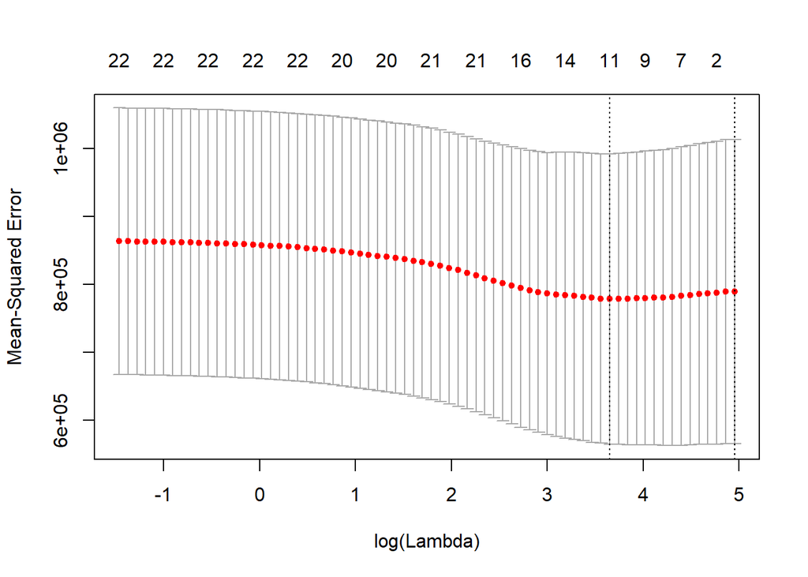

```r
plot(Lambda_ridge)
```

### Regolarizzazione

Applichiamo la regressione Ridge. Usiamo la funzione *glmnet*.

Come *cv.glmnet* ha come primo argomento la matrice dei predittori, come secondo il vettore delle risposte.

*Family* indica la popolazione da cui sono estratte le osservazioni nel vettore delle risposte.

*alpha* varia tra “0” e “1”, con “0” esegue la regressione Ridge, con “1” usa il metodo Lasso.

```r
RegCoef<-glmnet(z,y,family = "gaussian",alpha = 0)
data.frame(Df = RegCoef$df, Dev = RegCoef$dev.ratio, Lambda = RegCoef$lambda) %>% kable()
```

| Df | Dev | Lambda |
| --- | --- | --- |
| 22 | 0.0000000 | 141631.61646 |
| 22 | 0.0019143 | 129049.45401 |
| 22 | 0.0020978 | 117585.05620 |
| 22 | 0.0022985 | 107139.12390 |
| 22 | 0.0025181 | 97621.17943 |
| 22 | 0.0027581 | 88948.78291 |
| 22 | 0.0030205 | 81046.81820 |
| 22 | 0.0033071 | 73846.84225 |
| 22 | 0.0036202 | 67286.49232 |
| 22 | 0.0039619 | 61308.94580 |
| 22 | 0.0043348 | 55862.42803 |
| 22 | 0.0047415 | 50899.76389 |
| 22 | 0.0051847 | 46377.96916 |
| 22 | 0.0056674 | 42257.87821 |
| 22 | 0.0061929 | 38503.80478 |
| 22 | 0.0067645 | 35083.23288 |
| 22 | 0.0073857 | 31966.53517 |
| 22 | 0.0080604 | 29126.71629 |
| 22 | 0.0087923 | 26539.17910 |
| 22 | 0.0095857 | 24181.51157 |
| 22 | 0.0104447 | 22033.29273 |
| 22 | 0.0113739 | 20075.91573 |
| 22 | 0.0123777 | 18292.42671 |
| 22 | 0.0134608 | 16667.37794 |
| 22 | 0.0146279 | 15186.69402 |
| 22 | 0.0158837 | 13837.54998 |
| 22 | 0.0172330 | 12608.26018 |
| 22 | 0.0186803 | 11488.17710 |
| 22 | 0.0202304 | 10467.59911 |
| 22 | 0.0218876 | 9537.68646 |

[output cut: 70 more lines]

Per fare il grafico dei coefficienti ottenuti con *glmnet* usiamo la funzione *plot* e usiamo *abline* per aggiungere una linea verticale nel grafico, in corrispondenza dei valori di lambda: *lambda.min* e *lambda.1se*.

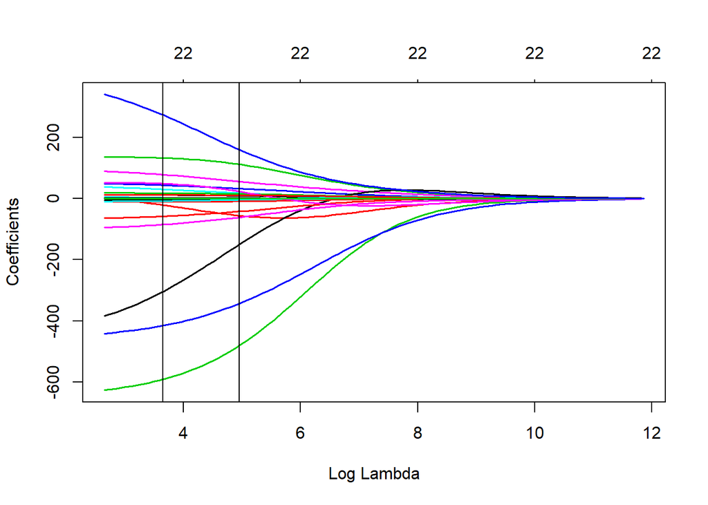

```r
plot(RegCoef, xvar="lambda", lwd=1.8)

abline(v=log(Lambda_ridge$lambda.1se))
abline(v=log(Lambda_ridge$lambda.min))
```

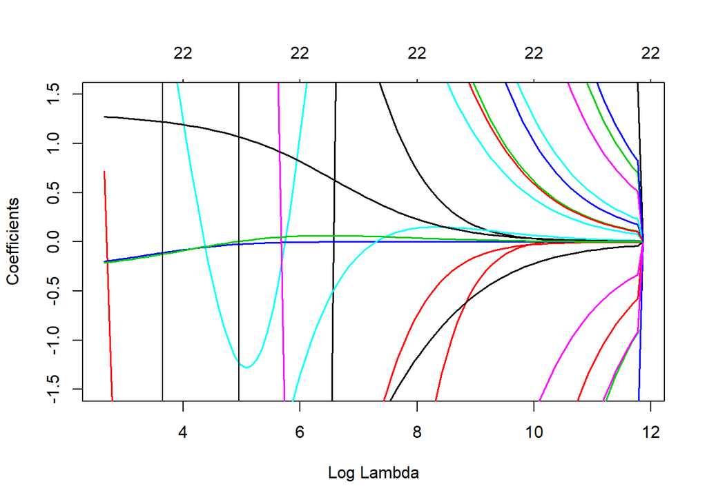

```r
plot(RegCoef, xvar="lambda",ylim=c(-1.5,1.5), lwd=1.8 )
abline(v=log(Lambda_ridge$lambda.1se))
abline(v=log(Lambda_ridge$lambda.min))
```

estraiamo i coefficienti stimati usando come parametro di regolarizzazione *lambda.1se*

```r
coefr<-coef(RegCoef, s=Lambda_ridge$lambda.1se)
data.frame(variables=rownames(coefr),coefficients=coefr[,1]) %>%kable
```

[output not shown]

Estraiamo i coefficienti stimati usando come parametro di regolarizzazione *lambda.min*

```r
coefr2<-coef(RegCoef, s=Lambda_ridge$lambda.min)
data.frame(variables=rownames(coefr2),coefficients=coefr2[,1]) %>%kable
```

| variables | coefficients |
| --- | --- |
| (Intercept) | -1634.6133922 |
| (Intercept) | 0.0000000 |
| AnniOLT | 11.7254702 |
| SexM | -21.3548865 |
| RangoOLT2 | 132.8937900 |
| BMI | 43.5786543 |
| MeldOLT | 29.9792379 |
| CreaOLTreal | 78.1813856 |
| Dialysis | -304.4097688 |
| PrevAbdSurg | -57.9765845 |
| LifeSupp | -590.8857402 |
| Ascites | -415.2618863 |
| PortalThromb | 2.5171727 |
| HCC | -85.1687180 |
| AgeD | -5.3700786 |
| BMID | -10.3797724 |
| SteaMacro | 17.7597735 |
| `D-MELD` | -0.1112869 |
| BAR | -7.9357041 |
| DRI | 48.9823338 |
| CIT | 1.2203708 |
| RWIT | 11.4917128 |
| GraftWeight | -0.1259456 |
| GRWR | 273.1375138 |